# Project: Comparing Performance of Different Models Configurations on the MNIST Dataset

- Background: The MNIST dataset consists of 28x28 grayscale images of handwritten digits (0-9) and is a widely used benchmark for evaluating machine learning algorithms in image classification tasks.
- Objective: In this project, my goal is to compare the performance of different deep learning models on the MNIST dataset to determine which model yields the highest accuracy in classifying the digits. Three different model configurations will be evaluated to assess their performance and identify the most suitable architecture for this image classification task.
- Model Development Process
  - Load data
  - Split the data into appropriate train, val, test splits
  - Plot sample images from train and test to better understand our data
  - Train the model
  - Plot the training statistics and observe the train and val acc and loss curves to investigate if model is learning properly, overfitting etc.
  - Evaluate model on test dataset

```python
import matplotlib.pyplot as plt
from sklearn.model_selection import train_test_split
import tensorflow as tf
from tensorflow.keras.models import Sequential
from tensorflow.keras.layers import Dense, Flatten, Dropout
from tensorflow.keras.datasets import mnist
import warnings

warnings.filterwarnings("ignore", category=UserWarning, module="keras")
```

```python
# load data

def load_mnist_dataset():
    (X_train, y_train), (X_test, y_test) = mnist.load_data()

    # check that the shape of each array is correct
    assert X_train.shape == (60000, 28, 28)
    assert X_test.shape == (10000, 28, 28)
    assert y_train.shape == (60000,)
    assert y_test.shape == (10000,)
    return X_train, y_train, X_test, y_test
```

```python
X_train, y_train, X_test, y_test = load_mnist_dataset()
```

```python
# plot some images to check dataset

def plot_sample_images(images, labels, num_cols=3, num_rows=3, width=4, height=4.5, title=None):
    _, _ = plt.subplots(num_cols, num_rows, figsize = (width, height))
    if title:
        plt.suptitle(title, fontsize=12)

    for i in range(num_cols*num_rows):
        plt.subplot(num_cols, num_rows, i+1)
        plt.imshow(images[i], cmap='gray')
        plt.title(labels[i])
        plt.axis('off')
    plt.show()
```

Before training the data, we need to plot some images to better understand our dataset.

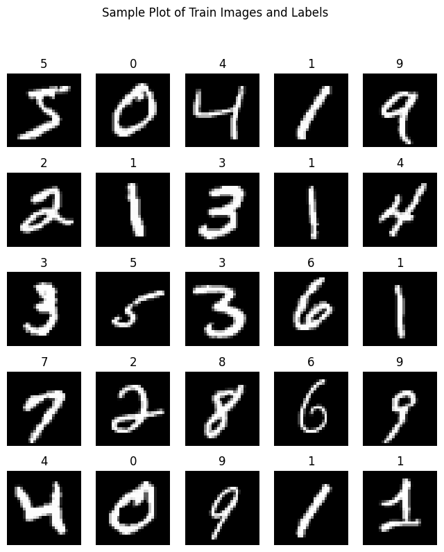

```python
# plot images to check - train dataset
plot_sample_images(
    images=X_train,
    labels=y_train,
    num_cols=5,
    num_rows=5,
    width=8,
    height=9,
    title="Sample Plot of Train Images and Labels"
)
```

we can see that the labels are correct and the images are readable

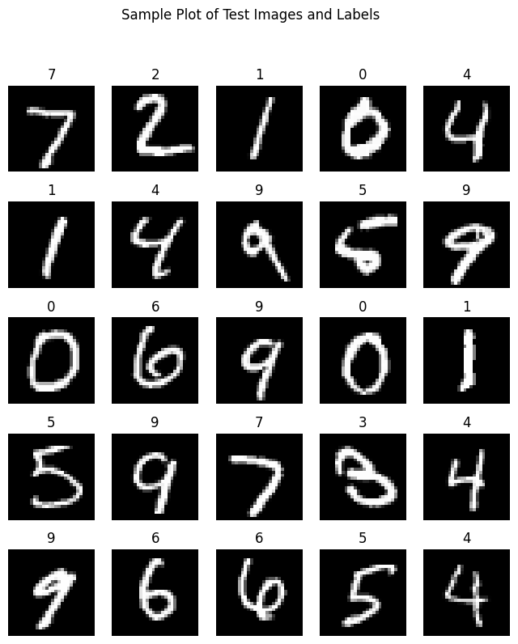

```python
# plot images to check - test dataset
plot_sample_images(
    images=X_test,
    labels=y_test,
    num_cols=5,
    num_rows=5,
    width=8,
    height=9,
    title="Sample Plot of Test Images and Labels"
)
```

we can run the train and test plots multiple times to check thru a sample of the dataset to verify that the labels for the data are correct

```python
def split_dataset(images, labels, test_size=0.2):
    X1, X2, y1, y2 = train_test_split(images, labels, test_size=test_size, random_state=42)
    return X1, y1, X2, y2
```

since the MNIST dataset already splits the train and test dataset, i would like to leave the test dataset untouched. To get the validation data, lets split the train data further into train and val at 0.85:0.15 train:val ratio (reasonable split)

```python
X_train, y_train, X_val, y_val = split_dataset(images=X_train, labels=y_train, test_size=0.15)
```

lets prepare our train and evaluate function (referencing teacher's tutorial/notes)

```python
def train(model, X_train, y_train, X_val, y_val, learning_rate=0.001, epochs=20, batch_size=32):
    model.compile(
        optimizer=tf.keras.optimizers.Adam(learning_rate=learning_rate),
        loss=tf.keras.losses.SparseCategoricalCrossentropy(from_logits=True),
        metrics=['accuracy']
    )

    # Train the model using the validation data for monitoring
    history = model.fit(
        X_train, y_train,
        epochs=epochs,
        batch_size=batch_size,
        validation_data=(X_val, y_val)
    )

    return history


def evaluate(model, X_test, y_test):
    # After model selection, evaluate the final model on the test set
    test_loss, test_accuracy = model.evaluate(X_test, y_test)
    print(f"\n\nTest Loss: {test_loss:.4f}")
    print(f"Test Accuracy: {test_accuracy:.4f}")
    return test_loss, test_accuracy
```

i will also prepare a function to plot the training statistics of the model training

```python
def plot_training_statistics(history):
    _, axes = plt.subplots(2, 2, figsize=(10, 8))

    train_acc, train_loss = history.history['accuracy'], history.history['loss']
    val_acc, val_loss = history.history['val_accuracy'], history.history['val_loss']
    epochs = range(1, len(train_acc) + 1)

    # Training Accuracy
    axes[0, 0].plot(epochs, train_acc, 'bo-', label="Training Accuracy")
    axes[0, 0].set_title("Training Accuracy")
    axes[0, 0].set_xlabel("Epochs")
    axes[0, 0].set_ylabel("Accuracy")
    axes[0, 0].legend()

    # Validation Accuracy
    axes[0, 1].plot(epochs, val_acc, 'r*-', label="Validation Accuracy")
    axes[0, 1].set_title("Validation Accuracy")
    axes[0, 1].set_xlabel("Epochs")
    axes[0, 1].set_ylabel("Accuracy")
    axes[0, 1].legend()

    # Training Loss
    axes[1, 0].plot(epochs, train_loss, 'bo-', label="Training Loss")
    axes[1, 0].set_title("Training Loss")
    axes[1, 0].set_xlabel("Epochs")
    axes[1, 0].set_ylabel("Loss")
    axes[1, 0].legend()

    # Validation Loss
    axes[1, 1].plot(epochs, val_loss, 'r*-', label="Validation Loss")
    axes[1, 1].set_title("Validation Loss")
    axes[1, 1].set_xlabel("Epochs")
    axes[1, 1].set_ylabel("Loss")
    axes[1, 1].legend()

    plt.tight_layout()
    plt.show()
```

to tie everything together, i will put all the different functions into a train_evaluate_function()

with this, we can easily train and evaluate different model configs just by running 1 function

```python
def train_evaluate_function(model):
    print("\n\n##### START TRAINING #####")
    history = train(
        model=model,
        X_train=X_train/X_train.max(), # normalise to btwn 0-1
        y_train=y_train,
        X_val=X_val/X_val.max(), # normalise to btwn 0-1
        y_val=y_val,
        epochs=10,
        batch_size=64
    )
    print("\n\n##### TRAINING COMPLETED #####")


    print("\n\n----- CHECK TRAINING STATISTICS -----")
    plot_training_statistics(history) # observe training and validation curves


    print("\n\n***** EVALUATE MODEL ON TEST DATASET *****")
    test_loss, test_accuracy = evaluate(
        model=history.model,
        X_test=X_test/X_test.max(),
        y_test=y_test
    ) # evaluate model on test set

    return history.model, test_loss, test_accuracy, history
```

# Model 1: SimpleFCN with 1 hidden layer

```python
class SimpleFCN():
    def __init__(self, input_shape=28):
        self.model =  Sequential([
                Flatten(input_shape=(input_shape, input_shape)),
                Dense(32, activation='relu'),
                Dense(10)
        ])
```

```
##### START TRAINING #####
797/797 ━━━━━━━━━━━━━━━━━━━━ 1s 524us/step - accuracy: 0.7855 - loss: 0.7427 - val_accuracy: 0.9251 - val_loss: 0.2605
797/797 ━━━━━━━━━━━━━━━━━━━━ 0s 448us/step - accuracy: 0.9341 - loss: 0.2352 - val_accuracy: 0.9422 - val_loss: 0.2048
797/797 ━━━━━━━━━━━━━━━━━━━━ 0s 446us/step - accuracy: 0.9489 - loss: 0.1867 - val_accuracy: 0.9510 - val_loss: 0.1705
797/797 ━━━━━━━━━━━━━━━━━━━━ 0s 464us/step - accuracy: 0.9560 - loss: 0.1558 - val_accuracy: 0.9542 - val_loss: 0.1552
797/797 ━━━━━━━━━━━━━━━━━━━━ 0s 445us/step - accuracy: 0.9600 - loss: 0.1408 - val_accuracy: 0.9573 - val_loss: 0.1423
797/797 ━━━━━━━━━━━━━━━━━━━━ 0s 446us/step - accuracy: 0.9654 - loss: 0.1208 - val_accuracy: 0.9586 - val_loss: 0.1420
797/797 ━━━━━━━━━━━━━━━━━━━━ 0s 447us/step - accuracy: 0.9689 - loss: 0.1085 - val_accuracy: 0.9607 - val_loss: 0.1319
797/797 ━━━━━━━━━━━━━━━━━━━━ 0s 444us/step - accuracy: 0.9721 - loss: 0.0952 - val_accuracy: 0.9646 - val_loss: 0.1204
797/797 ━━━━━━━━━━━━━━━━━━━━ 0s 445us/step - accuracy: 0.9759 - loss: 0.0861 - val_accuracy: 0.9659 - val_loss: 0.1191
797/797 ━━━━━━━━━━━━━━━━━━━━ 0s 447us/step - accuracy: 0.9761 - loss: 0.0821 - val_accuracy: 0.9657 - val_loss: 0.1145


##### TRAINING COMPLETED #####


----- CHECK TRAINING STATISTICS -----
```

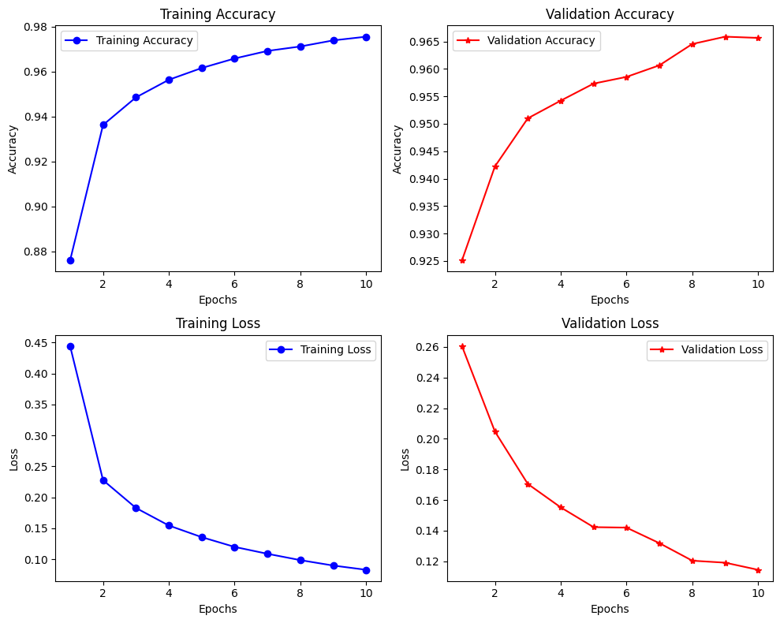

```
***** EVALUATE MODEL ON TEST DATASET *****
313/313 ━━━━━━━━━━━━━━━━━━━━ 0s 283us/step - accuracy: 0.9600 - loss: 0.1324


Test Loss: 0.1197
Test Accuracy: 0.9655
```

```python
model1, test_loss1, test_accuracy1, history1 = train_evaluate_function(
    model=SimpleFCN(input_shape=X_train.shape[1]).model
)
```

# Model 2: DeepFCN with multiple hidden layers

```python
class DeepFCN():
    def __init__(self, input_shape=28):
        self.model =  Sequential([
                Flatten(input_shape=(input_shape, input_shape)),
                Dense(256, activation='relu'),
                Dense(128, activation='relu'),
                Dense(64, activation='relu'),
                Dense(10)
        ])
```

```
##### START TRAINING #####
797/797 ━━━━━━━━━━━━━━━━━━━━ 1s 1ms/step - accuracy: 0.8637 - loss: 0.4644 - val_accuracy: 0.9661 - val_loss: 0.1164
797/797 ━━━━━━━━━━━━━━━━━━━━ 1s 1ms/step - accuracy: 0.9662 - loss: 0.1127 - val_accuracy: 0.9689 - val_loss: 0.0985
797/797 ━━━━━━━━━━━━━━━━━━━━ 1s 1ms/step - accuracy: 0.9791 - loss: 0.0689 - val_accuracy: 0.9722 - val_loss: 0.0925
797/797 ━━━━━━━━━━━━━━━━━━━━ 1s 1ms/step - accuracy: 0.9849 - loss: 0.0472 - val_accuracy: 0.9681 - val_loss: 0.1034
797/797 ━━━━━━━━━━━━━━━━━━━━ 1s 1ms/step - accuracy: 0.9891 - loss: 0.0351 - val_accuracy: 0.9638 - val_loss: 0.1287
797/797 ━━━━━━━━━━━━━━━━━━━━ 1s 1ms/step - accuracy: 0.9906 - loss: 0.0296 - val_accuracy: 0.9789 - val_loss: 0.0742
797/797 ━━━━━━━━━━━━━━━━━━━━ 1s 1ms/step - accuracy: 0.9914 - loss: 0.0250 - val_accuracy: 0.9783 - val_loss: 0.0823
797/797 ━━━━━━━━━━━━━━━━━━━━ 1s 1ms/step - accuracy: 0.9928 - loss: 0.0215 - val_accuracy: 0.9763 - val_loss: 0.0928
797/797 ━━━━━━━━━━━━━━━━━━━━ 1s 1ms/step - accuracy: 0.9951 - loss: 0.0160 - val_accuracy: 0.9824 - val_loss: 0.0783
797/797 ━━━━━━━━━━━━━━━━━━━━ 1s 1ms/step - accuracy: 0.9942 - loss: 0.0185 - val_accuracy: 0.9784 - val_loss: 0.0870


##### TRAINING COMPLETED #####


----- CHECK TRAINING STATISTICS -----
```

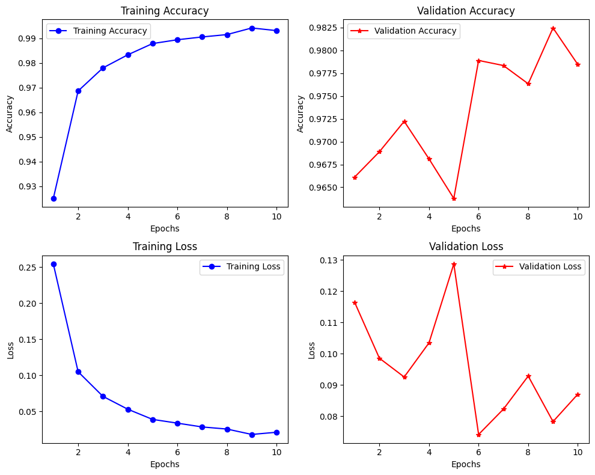

```
***** EVALUATE MODEL ON TEST DATASET *****
313/313 ━━━━━━━━━━━━━━━━━━━━ 0s 379us/step - accuracy: 0.9718 - loss: 0.1088


Test Loss: 0.0937
Test Accuracy: 0.9754
```

```python
model2, test_loss2, test_accuracy2, history2 = train_evaluate_function(
    model=DeepFCN(input_shape=X_train.shape[1]).model
)
```

# Model 3: DeepFCN with multiple hidden layers + Dropout

```python
class DeepFCN_Dropout():
    def __init__(self, input_shape=28, dropout=0.2):
        self.model =  Sequential([
                Flatten(input_shape=(input_shape, input_shape)),
                Dense(256, activation='relu'),
                Dropout(dropout),
                Dense(128, activation='relu'),
                Dropout(dropout),
                Dense(64, activation='relu'),
                Dropout(dropout),
                Dense(10)
        ])
```

```
##### START TRAINING #####
797/797 ━━━━━━━━━━━━━━━━━━━━ 2s 1ms/step - accuracy: 0.8033 - loss: 0.6293 - val_accuracy: 0.9568 - val_loss: 0.1402
797/797 ━━━━━━━━━━━━━━━━━━━━ 1s 1ms/step - accuracy: 0.9517 - loss: 0.1695 - val_accuracy: 0.9678 - val_loss: 0.1058
797/797 ━━━━━━━━━━━━━━━━━━━━ 1s 1ms/step - accuracy: 0.9636 - loss: 0.1252 - val_accuracy: 0.9699 - val_loss: 0.0966
797/797 ━━━━━━━━━━━━━━━━━━━━ 1s 1ms/step - accuracy: 0.9727 - loss: 0.0920 - val_accuracy: 0.9760 - val_loss: 0.0839
797/797 ━━━━━━━━━━━━━━━━━━━━ 1s 1ms/step - accuracy: 0.9741 - loss: 0.0858 - val_accuracy: 0.9792 - val_loss: 0.0723
797/797 ━━━━━━━━━━━━━━━━━━━━ 1s 1ms/step - accuracy: 0.9791 - loss: 0.0672 - val_accuracy: 0.9768 - val_loss: 0.0767
797/797 ━━━━━━━━━━━━━━━━━━━━ 1s 1ms/step - accuracy: 0.9810 - loss: 0.0619 - val_accuracy: 0.9797 - val_loss: 0.0710
797/797 ━━━━━━━━━━━━━━━━━━━━ 1s 1ms/step - accuracy: 0.9823 - loss: 0.0597 - val_accuracy: 0.9819 - val_loss: 0.0708
797/797 ━━━━━━━━━━━━━━━━━━━━ 1s 1ms/step - accuracy: 0.9835 - loss: 0.0531 - val_accuracy: 0.9796 - val_loss: 0.0726
797/797 ━━━━━━━━━━━━━━━━━━━━ 1s 1ms/step - accuracy: 0.9864 - loss: 0.0455 - val_accuracy: 0.9820 - val_loss: 0.0692


##### TRAINING COMPLETED #####


----- CHECK TRAINING STATISTICS -----
```

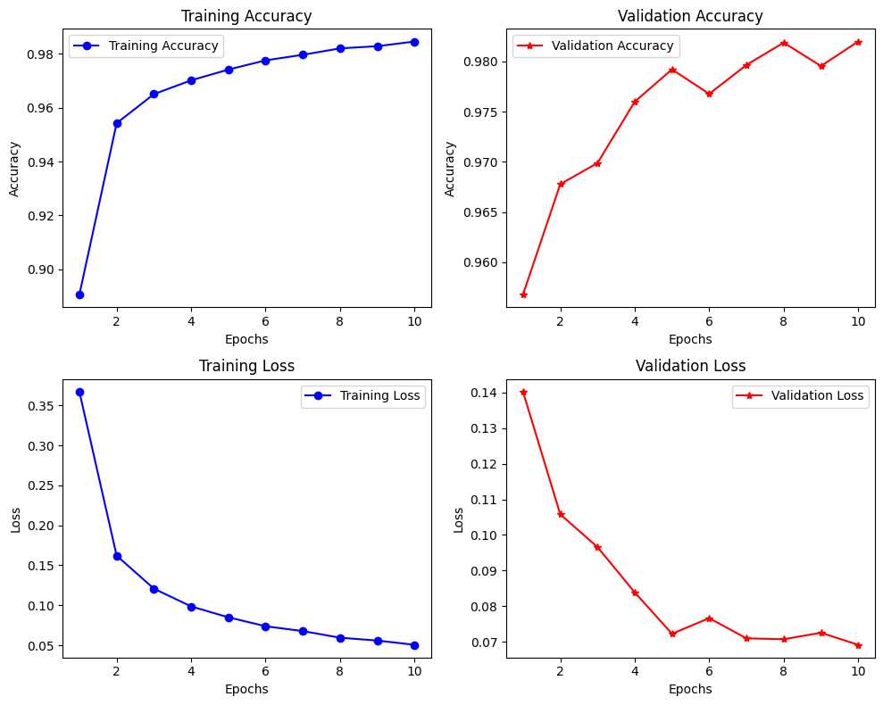

```
***** EVALUATE MODEL ON TEST DATASET *****
313/313 ━━━━━━━━━━━━━━━━━━━━ 0s 380us/step - accuracy: 0.9767 - loss: 0.0859


Test Loss: 0.0745
Test Accuracy: 0.9800
```

```python
model3, test_loss3, test_accuracy3, history3 = train_evaluate_function(
    model=DeepFCN_Dropout(input_shape=X_train.shape[1]).model
)
```

# Comparison of Results

In this experiment, three different models were trained on the MNIST dataset to evaluate their performance in digit classification. The models are:

1. Simple FCN: A fully connected neural network with a single dense layer.
2. Deep FCN: A deeper fully connected neural network with multiple dense layers.
3. Deep FCN with Dropout: The same architecture as the second model, but with dropout layers added to regularize the network and reduce overfitting.

The aim was to compare their performance based on test accuracy and loss, as well as to examine the stability of the training curves during training.

## Model Descriptions and Test Results

1. Model 1: Simple FCN (Single Layer)
   - This model consists of a single fully connected (dense) layer, which is trained on the 28x28 grayscale MNIST images (flattened to 784 input features). The architecture is straightforward, with no additional regularization techniques, making it suitable for a baseline comparison.
   - Test Results for Model 1:
     - Test Loss: 0.1197
     - Test Accuracy: 0.9655
2. Model 2: Deep FCN (Multiple Layers)
   - Model 2 is an enhanced version of the Simple FCN, containing multiple dense layers (256, 128, and 64 units). The additional layers increase the model's capacity to capture more complex patterns in the data. However, deeper networks are prone to overfitting, especially with small datasets like MNIST.
   - Test Results for Model 2:
     - Test Loss: 0.0937
     - Test Accuracy: 0.9754
3. Model 3: Deep FCN with Dropout
   - Model 3 is similar to Model 2 but includes dropout layers after each dense layer. Dropout is a regularization technique that helps prevent overfitting by randomly "dropping" units during training, forcing the network to learn more robust features. This model is expected to show improved generalization over Model 2.
   - Test Results for Model 3:
     - Test Loss: 0.0745
     - Test Accuracy: 0.9800

## Comparison and Analysis - Test Accuracy and Loss

1. Model 1: The simple model achieves a test accuracy of 96.55% with a test loss of 0.1197. While these are decent results, the performance could be improved with a deeper model.
2. Model 2: The deep model improves the accuracy to 97.54% and reduces the test loss to 0.0937, demonstrating the benefit of adding more layers. The increased number of parameters allows the model to capture more complex features from the data, leading to better performance.
3. Model 3: Adding dropout to the deep model yields the best results, with a test accuracy of 98.00% and a test loss of 0.0745. This confirms that dropout helps to regularize the model, preventing overfitting while maintaining high accuracy.

## Comparison and Analysis - Training Stability

1. Model 1 shows a stable training curve, suggesting that the model does not experience overfitting or underfitting, but its relatively simple structure limits its ability to capture complex patterns.
2. Model 2, with its deep architecture, experiences more fluctuations in the training curve, which can indicate overfitting or difficulty in convergence. This can happen due to the large number of parameters and the risk of overfitting to the training data.
3. Model 3 benefits from dropout, which stabilizes the training process by preventing overfitting. This results in a smoother and more consistent training curve, ultimately improving generalization and model performance.

# Conclusion

- Model 1 is a good baseline model but is limited by its simplicity. While it performs well on MNIST, it fails to fully leverage the complexity of the data.
- Model 2, with multiple dense layers, shows improved performance compared to Model 1. However, it struggles with training instability due to overfitting and the increased complexity of the model.
- Model 3, which introduces dropout regularization, outperforms both Model 1 and Model 2 by achieving the highest test accuracy (98%) and the lowest test loss (0.0745). The addition of dropout not only improves performance but also stabilizes the training process, demonstrating the importance of regularization in deep learning models.

Overall, the results highlight the effectiveness of adding more layers and regularization techniques, such as dropout, to improve model performance and stability on complex tasks like digit classification with the MNIST dataset.

# Full Workflow

- this section shows the full model development process, using the SimpleFCN model
  - Load data
  - Split the data into appropriate train, val, test splits
  - Plot sample images from train and test to better understand our data
  - Train the model
  - Plot the training statistics and observe the train and val acc and loss curves to investigate if model is learning properly, overfitting etc.
  - Evaluate model on test dataset

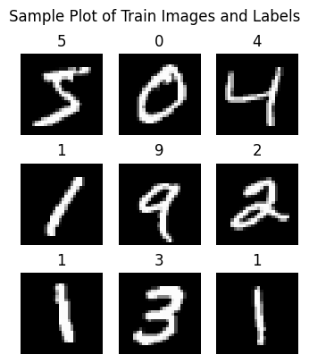

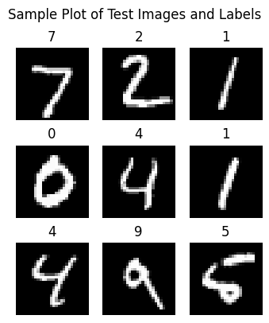

```
##### START TRAINING #####
797/797 ━━━━━━━━━━━━━━━━━━━━ 1s 529us/step - accuracy: 0.8085 - loss: 0.7228 - val_accuracy: 0.9288 - val_loss: 0.2507
797/797 ━━━━━━━━━━━━━━━━━━━━ 0s 456us/step - accuracy: 0.9311 - loss: 0.2426 - val_accuracy: 0.9367 - val_loss: 0.2089
797/797 ━━━━━━━━━━━━━━━━━━━━ 0s 457us/step - accuracy: 0.9450 - loss: 0.1921 - val_accuracy: 0.9476 - val_loss: 0.1822
797/797 ━━━━━━━━━━━━━━━━━━━━ 0s 456us/step - accuracy: 0.9526 - loss: 0.1645 - val_accuracy: 0.9519 - val_loss: 0.1638
797/797 ━━━━━━━━━━━━━━━━━━━━ 0s 452us/step - accuracy: 0.9580 - loss: 0.1466 - val_accuracy: 0.9577 - val_loss: 0.1455
797/797 ━━━━━━━━━━━━━━━━━━━━ 0s 459us/step - accuracy: 0.9629 - loss: 0.1277 - val_accuracy: 0.9620 - val_loss: 0.1380
797/797 ━━━━━━━━━━━━━━━━━━━━ 0s 452us/step - accuracy: 0.9662 - loss: 0.1182 - val_accuracy: 0.9623 - val_loss: 0.1323
797/797 ━━━━━━━━━━━━━━━━━━━━ 0s 455us/step - accuracy: 0.9665 - loss: 0.1111 - val_accuracy: 0.9618 - val_loss: 0.1335
797/797 ━━━━━━━━━━━━━━━━━━━━ 0s 449us/step - accuracy: 0.9708 - loss: 0.0977 - val_accuracy: 0.9616 - val_loss: 0.1314
797/797 ━━━━━━━━━━━━━━━━━━━━ 0s 448us/step - accuracy: 0.9724 - loss: 0.0942 - val_accuracy: 0.9638 - val_loss: 0.1214


##### TRAINING COMPLETED #####


----- CHECK TRAINING STATISTICS -----
```

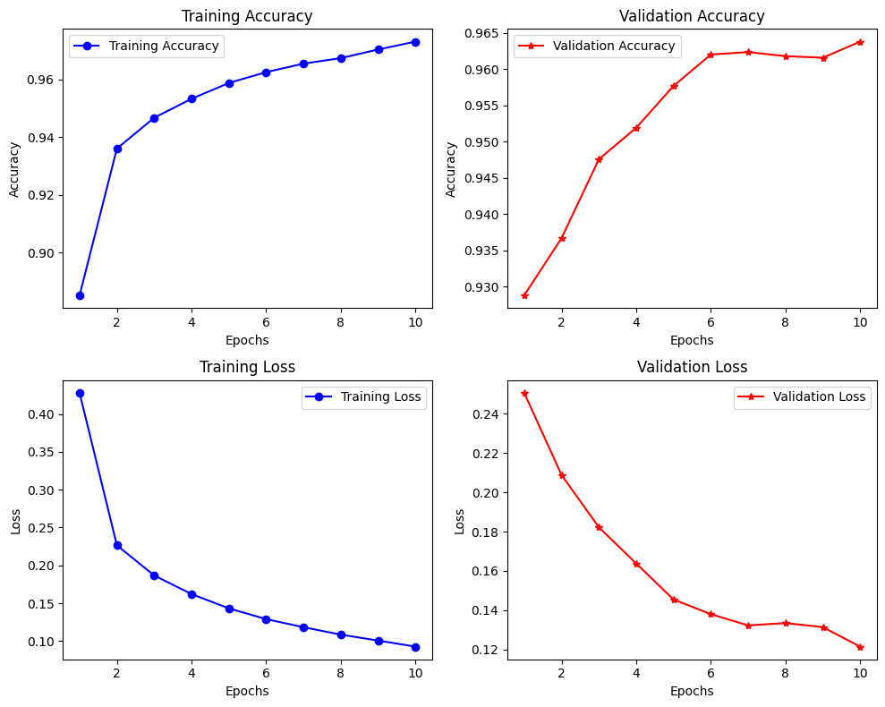

```
***** EVALUATE MODEL ON TEST DATASET *****
313/313 ━━━━━━━━━━━━━━━━━━━━ 0s 283us/step - accuracy: 0.9611 - loss: 0.1341


Test Loss: 0.1219
Test Accuracy: 0.9641
```

```python
def main(model):
    X_train, y_train, X_test, y_test = load_mnist_dataset() # load data
    plot_sample_images(images=X_train, labels=y_train, title="Sample Plot of Train Images and Labels") # plot images to check - train dataset
    plot_sample_images(images=X_test, labels=y_test, title="Sample Plot of Test Images and Labels") # plot images to check - test dataset
    X_train, y_train, X_val, y_val = split_dataset(images=X_train, labels=y_train, test_size=0.15)

    print("\n\n##### START TRAINING #####")
    history = train(
        model=model,
        X_train=X_train/X_train.max(), # normalise to btwn 0-1
        y_train=y_train,
        X_val=X_val/X_val.max(), # normalise to btwn 0-1
        y_val=y_val,
        epochs=10,
        batch_size=64
    )
    print("\n\n##### TRAINING COMPLETED #####")


    print("\n\n----- CHECK TRAINING STATISTICS -----")
    plot_training_statistics(history) # observe training and validation curves


    print("\n\n***** EVALUATE MODEL ON TEST DATASET *****")
    test_loss, test_accuracy = evaluate(
        model=history.model,
        X_test=X_test/X_test.max(),
        y_test=y_test
    ) # evaluate model on test set

    return history.model, test_loss, test_accuracy, history


model4, test_loss4, test_accuracy4, history4 = main(
    model=SimpleFCN(input_shape=X_train.shape[1]).model
)
```